# Effects of Class Size on Math Performance in Tennessee

1/10/2020

# Introduction

### Background

The Student/Teacher Achievement Ratio (STAR) was a four-year longitudinal class-size study funded by the Tennessee General Assembly and conducted by the State Department of Education. Over 7,000 students from kindergarten to 3rd grade in 79 schools were randomly assigned into one of three interventions: small class (13 to 17 students per teacher), regular class (22 to 25 students per teacher), and regular-with-aide class (22 to 25 students with a full-time teacher’s aide). Classroom teachers were also randomly assigned to the classes they would teach. The interventions were initiated as the students entered school in kindergarten and continued through third grade.

The STAR experiment was designed by a group of researchers including Helen Pate-Bain, the driving force behind Project STAR, other academics, and members of the Tennessee Department of Education. Some of its key features are:

1. *All Tennessee schools with K-3 classes were invited to participate.* Giving every school a chance to join the study helped ensure a diverse sample as well as rule out the possibility that class-size effects could be attributed to selection bias.
2. *Each school included in the study had to have a large enough student body to form as least one of each of the three class types.* The within-school design provided built-in control for differences among schools in terms of resources, leadership, and facilities.
3. *Schools from inner-city, urban, suburban and rural locations were included in the experiment.* This feature guaranteed that samples would include children from various ethnic backgrounds and income levels.
4. *Students and teachers were randomly assigned to their class type.*
5. *Investigators followed the standard procedures for confidentiality in human subjects’ research.*
6. *No children were to receive fewer services than normal because of the experiment.*
7. *Student achievement was to be tracked by standardized tests, which were carefully monitored.*

### Questions of Interest

For our analysis, we will consider the following questions.

1. Is there a significant difference in the mean math scores in the 1st grade across different class types?
2. Is the ANOVA model a good fit for the purpose of this analysis? In other words, are the assumptions of the ANOVA model satisfied? To explore this question, we will use model diagnostics such as residual plots and a Levene test for equality of variances.
3. Can we conclude that class sizes affect the scaled math scores of first grade students?

# Methods & Analysis

### Descriptive Analysis

There are 11,598 rows and 47 columns in the STAR data set. Each row represents a student that participated in the experimental phase for at least one year. Each column represents information including demographic variables. These variables include school type, class type, and scores from different subject tests. For our analysis, we will primarily focus on the type of class and the scaled math score of first graders.

The table below shows descriptive statistics of the 1st grade students in the data set, after removing records with missing values.

|  | regular (n=2505) | small (n=1868) | regular+aide (n=2225) | Overall (n=6598) |
| --- | --- | --- | --- | --- |
| gender |  |  |  |  |
| male | 1282 (51.2%) | 962 (51.5%) | 1170 (52.6%) | 3414 (51.7%) |
| female | 1223 (48.8%) | 906 (48.5%) | 1055 (47.4%) | 3184 (48.3%) |
| ethnicity |  |  |  |  |
| cauc | 1559 (62.2%) | 1272 (68.1%) | 1571 (70.6%) | 4402 (66.7%) |
| afam | 929 (37.1%) | 582 (31.2%) | 642 (28.9%) | 2153 (32.6%) |
| asian | 9 (0.4%) | 6 (0.3%) | 4 (0.2%) | 19 (0.3%) |
| hispanic | 2 (0.1%) | 3 (0.2%) | 4 (0.2%) | 9 (0.1%) |
| amindian | 2 (0.1%) | 2 (0.1%) | 0 (0%) | 4 (0.1%) |
| other | 4 (0.2%) | 3 (0.2%) | 4 (0.2%) | 11 (0.2%) |
| math1 |  |  |  |  |
| Mean (SD) | 525 (41.7) | 539 (44.1) | 530 (42.9) | 531 (43.1) |
| Median [Min, Max] | 523 [408, 676] | 535 [425, 676] | 529 [404, 676] | 529 [404, 676] |

The distribution of the number of 1st grade students in each class type is displayed in the pie chart below:

[interactive chart not shown]

We observe that 38% of students are enrolled in a regular class, 33.7% of students are enrolled in a regular+aide class, and 28.3% of students are enrolled in a small class.

#### School Type

The project include four types of schools to assess the effects of class size in different school locations. They are inner-city, suburban, urban, and rural schools. Inner-city and suburban schools were located in metropolitan areas, and urban or rural schools were located in non-metropolitan areas.

According to the box plot, students in suburban and rural schools performed better on the total math scaled score in 1st grade. Besides, the bar plot shows that in all types of schools, students in small classes performed slightly better than students in regular classes or regular classes with a full-time teacher aide. However, the effect of school type is not very obvious in this plot, and further analysis might be needed.

[interactive chart not shown]

#### Class Type

Considering that some schools might drop out of the project, or the class type might be changed if schools gain or lose students, here we only select students that had full records of math scaled scores, and remained in the same type of class from kindergarten to the 3rd grade.

According to the line plot, the performance of students in regular classes and the performance of students in regular classes with a full-time teacher aide are not very different. However, the students in small classes performed better on the total math scaled score from kindergarten to the 3rd grade.

[interactive chart not shown]

### One-Way ANOVA Model

For our analysis, we will use a variation of the factor effects model to capture the effect of the different class treatments. This model is most useful in our analysis because it represents the expected change in math score compared to a student enrolled in the standard regular class treatment. As shown above, the study effectively randomized many of the different demographic features of participants. This randomization allows us to use this simplified model to generalize the impact of class sizes on test scores across all demographics. Moreover, since our primary question examines the effect of class size on math scores, defining the model in this way allows us to examine the effect of each treatment compared to the regular class treatment.

The final model selected in this analysis is described below.

$$MathScore = \mu +T_2X_2 + T_3X_3 + \epsilon_{i,j}$$

where:

$X_2 = 1$ if the student is assigned to a small class and $0$ otherwise.  
$X_3 = 1$ if the student is assigned to a regular + aide class and $0$ otherwise.

In this model, $\mu$ represents the average first-grade math test-score for students enrolled in regular classes. Furthermore, $T_2$ represents the average change in score for students enrolled in small classes and $T_3$ represents the average change in score for students enrolled in regular+aide classes, both compared to the regular class treatment.

To facilitate pair-wise analysis, we used $\mu_i$ to denote the group mean for each class type, where:  
$\mu_i = \mu$ for $i = 1$;  
$\mu_i = \mu + T_iX_i$ for $i = 2, 3$

Before fitting the model described above, it is important to examine the model assumptions.

1. Normality

[interactive chart not shown]

2. Independence

It is not reasonable to assume a strict independence of our samples through this study. Students may study together, teachers may share materials, or parents may seek out tutoring for their child. However, this study represents the most controlled and robust method we could possible obtain to examine the effects of class size on math test scores of first graders. Paired with the large sample size, while these samples are not strictly independent we can consider them practically independent since the study represents the most controlled environment we could possible obtain.

3. Equality of Variance

From the histograms pictured above, it does appear that the distribution of first-grade test scores across the three treatments have the same variance. And after specifying an alpha of $.05$ The Levene test for equality of variances did not return significant evidence that the variances between groups were significantly different. Therefore, we may assume equality of variances between treatment groups.

Levene’s Test for Equal Variance

|  | Df | F value | Pr(>F) |
| --- | --- | --- | --- |
| group | 2 | 2.826011 | 0.0593205 |
|  | 6595 | NA | NA |

With all three of our model assumptions verified, we can continue to fit our ANOVA model.

#### Model Results

After fitting the factor effect model described above, we found significant evidence to suggest that at least one of the classroom treatments exhibited a different score distribution compared to that of regular class size.

ANOVA Table

|  | Df | Sum Sq | Mean Sq | F value | Pr(>F) |
| --- | --- | --- | --- | --- | --- |
| star1 | 2 | 194888.1 | 97444.050 | 53.26329 | 0 |
| Residuals | 6595 | 12065411.8 | 1829.479 | NA | NA |

Both the Regular+Aide & Small class sizes returned an increase in average math scores compared to the regular class treatment group. The average score for students in regular classes was 525.28. Students enrolled in Regular + Aide classes performed on average 4.35 scaled points higher than regular class students. Similarly, Students enrolled in small classes performed on average 13.40 scaled points higher than regular class students.

[interactive chart not shown]

Effect of Each Class Size

| Class.Size | Average.Math.Score | Change.from.Regular | Significant |
| --- | --- | --- | --- |
| Regular | 525.28 |  |  |
| Small (T2) | 538.68 | 13.4 | YES |
| Regular + Aide (T3) | 529.63 | 4.35 | YES |

#### Model Diagnostic

Before validating out model, we must return to our assumptions and ensure that they were not violated.

1. Normality

From the residual normal Q-Q plot below, we can observe that our specified model follows the expected Q-Q quite well. While there are some minor deviations at the tails, which we observed earlier in the the Histogram, the overall trend of the data demonstrates a largely normal distribution. Therefore, we can satisfy the normality assumption.

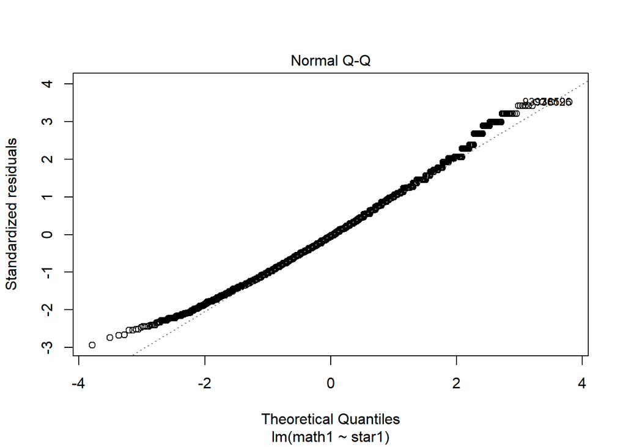

2. Independence

From the Residual vs Fitted plot below, it is clear that our data is independent and randomly distributed about zero. Therefore, assumption of independence was satisfied.

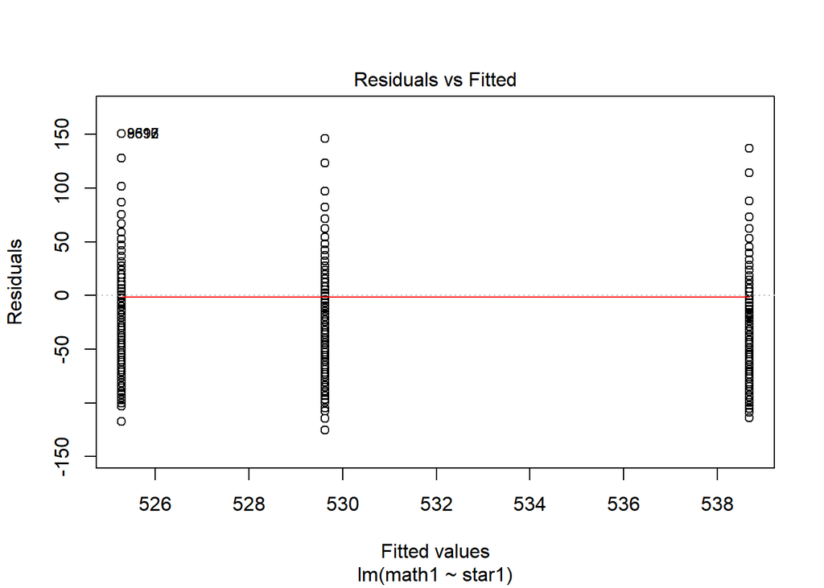

3. Equality of Variance

With all three model assumptions supported by residuals, we move forward and validate this model. That is to say, this model is behaving the way we expect it to and is therefore a useful and informative model.

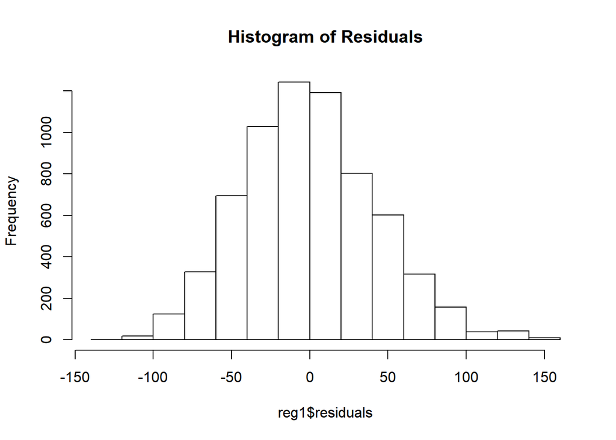

#### Further Tests

Since there is no violation for ANOVA model assumptions, an F-test was used to test whether there is a difference in the math scaled score in 1st grade across students in different types of classes. The null and alternative hypotheses were shown as below.

$$H_0: \mu1 = \mu2 = \mu3 \ V.S \ H_a: not\ all\ \mu_i's\ are\ equal$$

Since $F^* = \frac{MSTR}{MSE} = 53.26 > F(1-\alpha; r, n_T-r) = 2.997093$, we reject the null hypothesis at level of 0.05. Not all class types have the same math scaled score.

To further investigate the difference among the class types, multiple comparisons were used. The hypotheses were shown as below.

$$H_0: D_{ij} = \mu_i-\mu_j, 1\leq i < j \leq3$$

The multipliers of Bonferroni’s procedure, Tukey’s procedure, and Scheffé’s procedure were shown in the table below. It is shown that the Scheffé’s multiplier is the smallest. So the Scheffé’s procedure was used to construct the confidence intervals.

| Procedure | Multiplier |
| --- | --- |
| Bonferroni | 2.39459079786542 |
| Tukey | 2.34423094428225 |
| Scheffé | 2.2830924522205 |

According the Confidence Intervals, zero is not contained in all the C.I.s. Therefore, at the family-wise significance level 0.05, we would reject all the null hypotheses.

| $D_{ij}$ | $\hat D_i$ | $CI$ |
| --- | --- | --- |
| $\mu_1 - \mu_2$ | -13.3982890749551 | [ -16.38357 , -10.41301 ] |
| $\mu_2 - \mu_3$ | 9.0525616533937 | [ 5.988097 , 12.11703 ] |
| $\mu_1 - \mu_3$ | -4.34572742156138 | [ -7.190509 , -1.500946 ] |

Our ANOVA model and confidence intervals all demonstrated significant evidence that the scaled math scores for first grade students in small and regular + aide classes were both significantly higher than the scaled math scored for students enrolled in regular classes. Scaled math score of small classes was also significantly higher than that of regular + aide classes in 1st grade.

# Conclusions

Through our analysis, we found significant evidence which demonstrated that on average, students enrolled in both small & regular + aide classes outperformed their peers enrolled in regular sized classes in first-grade math. Because of the high sample size and the rigorously randomized nature of the study, we may make a limited causal inference into the effect of class sizes on a student’s mathematical performance. With over 6,000 evaluations of first grade students, we feel confident that we have observed the potential average outcomes of each of the three treatments. Because of this, we can conclude that, the student to instructor ratios in first grade math classes have a causal relationship with the average performance on a standardized math test.

While we can not make any specific conclusions about the causal effect of class size with an individual student’s performance, our average causal conclusion is of great significance for policy makers and educators. We have demonstrated that for Tennessee students, enrolling in smaller class sizes or in regular-size classes with an aide in the first grade help them perform better, on average, on the standardized math test. With this conclusion, schools should attempt to provide their students with the best student to teacher ratio possible to provide them the best opportunity to learn and perform on standardized math tests.

# Reference

https://www.wqqaft.org/sites/default/files/periodicals/STARSummer99.pdf